# Hw 2

Max Gehred

2022-10-13

#Introduction

##Data Cleaning

```r
modflights <- flights %>% mutate(pos_arr_delay=replace(arr_delay,arr_delay<0,0)) %>% mutate(pos_dep_delay=replace(dep_delay,dep_delay<0,0)) %>%
  mutate(total_delay = pos_dep_delay + pos_arr_delay) %>%
  mutate(sched_dep_hour = substring(sched_dep_time,1,nchar(sched_dep_time)-2))
```

##The best time to fy, to avoid delays

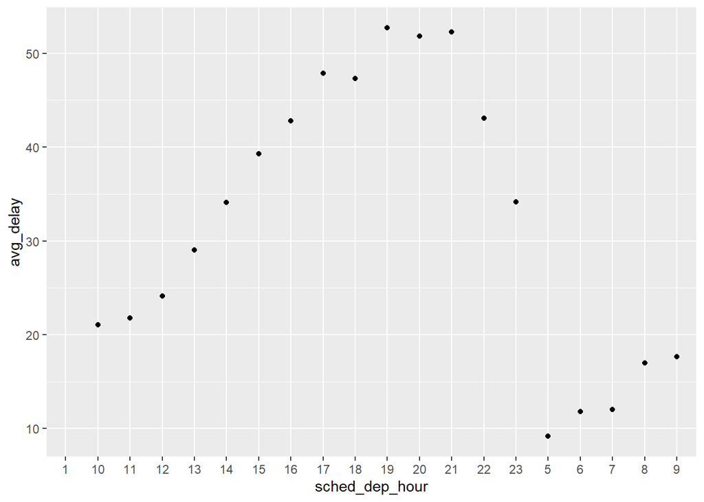

Introduction:

I go on to investigate how season, origin, and flight distance affect the graph above, and optimal departure time to avoid delays. In doing so, I found that the optimal departure time remained constant near 5am, and never going later than 7am for any subsect of the data I investigated.

#By Season

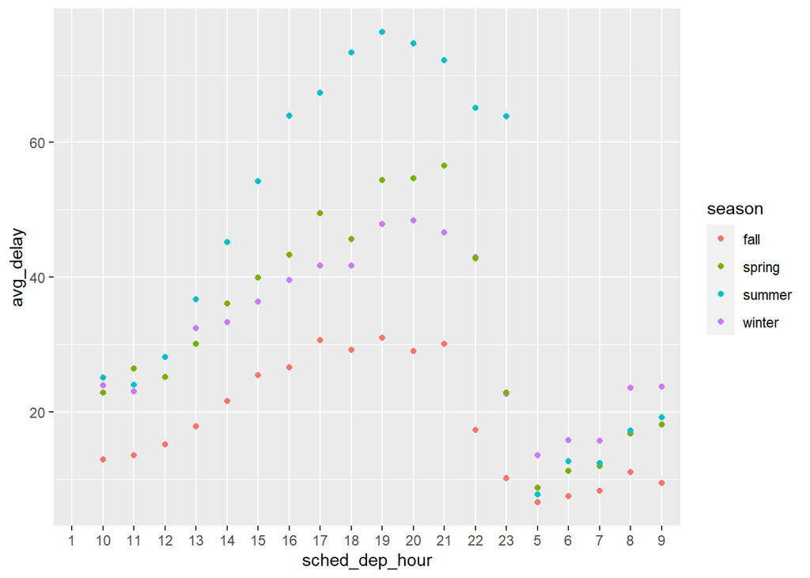

Based on the results above, season does have some impact on average departure delay, but the optimal departure hour does not depend on season. Whether Fall Winter Summer or Spring, the optimal departure time is 5AM. Interestingly, the variance of delays are much greater in the summer, which makes an early morning departure more valuable in that season.

#ByOrigin

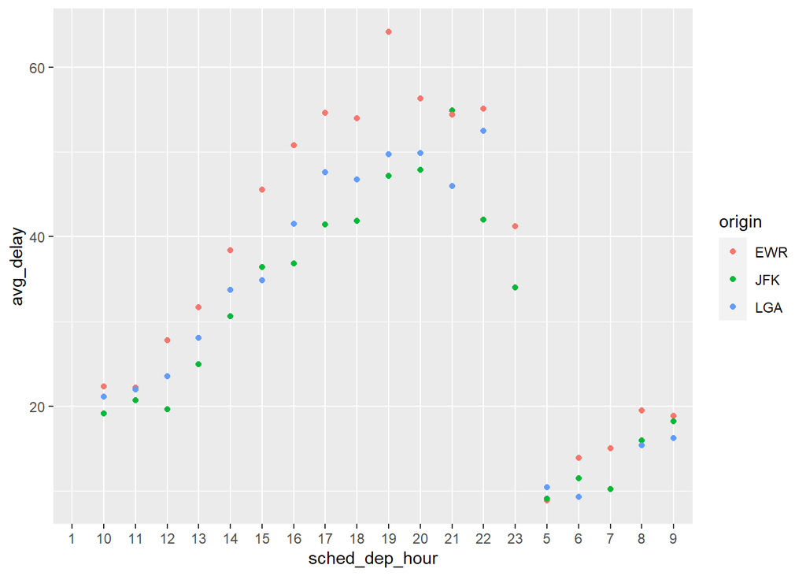

```r
modflights2 %>% group_by(origin,sched_dep_hour) %>% arrange(sched_dep_hour) %>% mutate(avg_delay=mean(total_delay, na.rm=TRUE)) %>% ggplot()+ geom_point(mapping=aes(x=sched_dep_hour,y= avg_delay, color = origin))
```

#byDistance

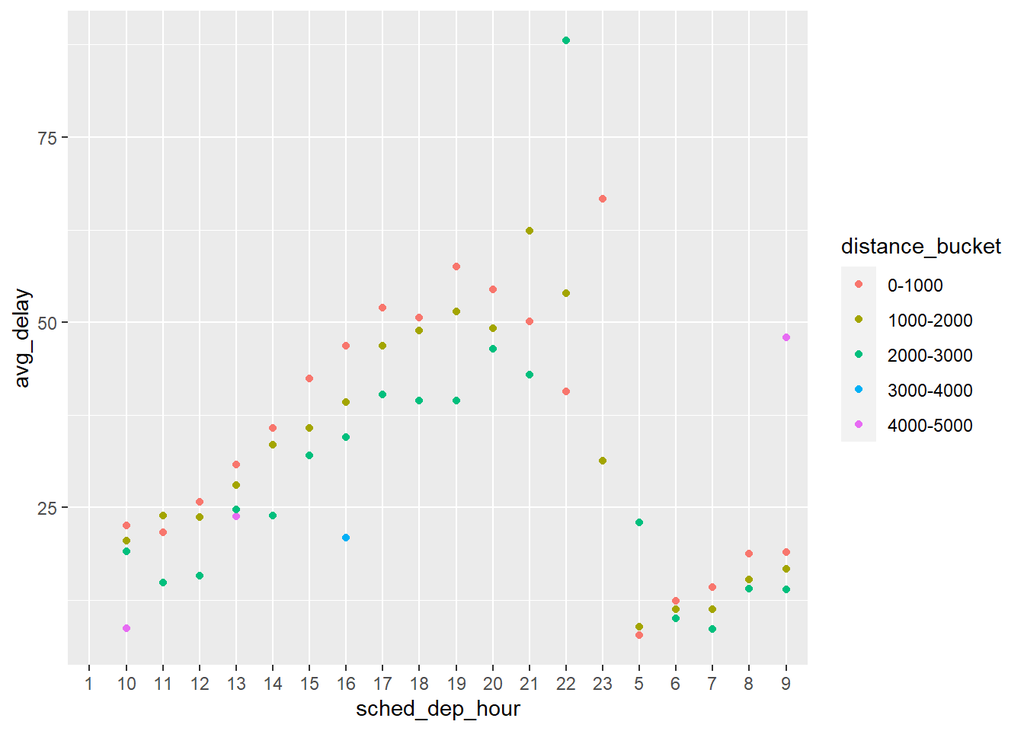

```r
modflights2 = modflights %>% mutate(distance_bucket = case_when(distance < 1000 ~ "0-1000", distance > 1000 & distance < 2000 ~ "1000-2000", distance > 2000 & distance < 3000 ~ "2000-3000", distance > 3000 & distance < 4000 ~ "3000-4000",distance > 4000 & distance < 5000 ~ "4000-5000"))

modflights2 %>% group_by(distance_bucket,sched_dep_hour) %>% arrange(sched_dep_hour) %>% mutate(avg_delay=mean(total_delay, na.rm=TRUE)) %>% ggplot()+ geom_point(mapping=aes(x=sched_dep_hour,y= avg_delay, color = distance_bucket))
```

Distance does not appear to be a factor in optimal departure times. 3000-4000, and 4000-5000 flights have a negligible count, so I will disregard them here.

Once again, the optimal time to leave is somewhere in the early morning, usually around 5, 6, or 7 am. Interestingly, 2000-3000 mile flights have very average delay at 5am, but have standardly low delays at 6 and 7.